# Biostats_HW2_P6

Biostats@CUMC

September 27, 2018

# Problem 3

We are given that 8% percent of men and 30% of women are **colorblind**.

**(A)**

If 10 men were randomly selected for a study on traffic signal perceptions, find the probability that exactly half of them cannot distinguish between red and green.

So here we have a binomial distribution with the probability of success being the probability that the man selected in colorblind = p = 8% = 0.08

N is the number of trials = 10

x is the number of success = 5

Therefore, X - Random variable denoting colorblind men: *X ~ Bin(N,p)* = *X ~ Bin(10, 0.08)*

Using these values in the dbinom function in R gives us: P(X = 5) = 5.442389410^{-4}

**(B)**

What if we would randomly select 10 women instead? How would the probability change?

So here we have a binomial distribution with the probability of success being the probability that the woman selected in colorblind = 30% = 0.3

N is the number of trials = 10

x is the number of success = 5

Therefore, X - Random variable denoting colorblind women: *X ~ Bin(N,p)* = *X ~ Bin(10, 0.30)*

Using these values in the dbinom function in R gives us: P(X = 5) = 0.1029193

# Problem 6

Here we import the data set

```r
migraine <- read_excel("C:/Users/abhis/OneDrive/Desktop/School/Semester 1/P8130_biostats/HW2/migraine.xlsx")
View(migraine)
```

Here we work on the first, **A** part of the question. Summarizing NDDIE, CSED, Cognitive Evaluation with the original scores. We take into consideration the follwoing parameters:

- Minimum value
- 1st Quartile
- Median
- Mean
- 3rd Quartile
- Maximum value
- Number of NA’s
- Standard Deviation
- Variance
- Size

```r
#NDDIE
s_nddie_1 = summary(migraine$NDDIE[which(migraine$Migraine == 1)])

sd_nddie_1 = sd(migraine$NDDIE[which(migraine$Migraine == 1)], na.rm = TRUE)

var_nddie_1 = var(migraine$NDDIE[which(migraine$Migraine == 1)], na.rm = TRUE)

s_nddie_0 = summary(migraine$NDDIE[which(migraine$Migraine == 0)])

sd_nddie_0 = sd(migraine$NDDIE[which(migraine$Migraine == 0)], na.rm = TRUE)

var_nddie_0 = var(migraine$NDDIE[which(migraine$Migraine == 0)], na.rm = TRUE)

with_migraine = data.frame(rbind((data.frame(unclass(s_nddie_1))), 'sd' = sd_nddie_1, 'var' = var_nddie_1, 'size' = nrow(migraine[which(migraine$Migraine == 1),])))

colnames(with_migraine) = 'nddie_w_migraine'

without_migraine = data.frame(rbind((data.frame(unclass(s_nddie_0))), 'sd' = sd_nddie_0, 'var' = var_nddie_0, 'size' = nrow(migraine[which(migraine$Migraine == 0),])))

colnames(without_migraine) = 'nddie_w/o_migraine'

data.frame(with_migraine, without_migraine)
```

```
##         nddie_w_migraine nddie_w.o_migraine
## Min.            6.000000            6.00000
## 1st Qu.         8.000000            6.00000
## Median         11.000000            9.00000
## Mean           11.424658           10.28571
## 3rd Qu.        14.000000           13.00000
## Max.           23.000000           24.00000
## NA's            9.000000           64.00000
## sd              4.361822            4.48925
## var            19.025495           20.15336
## size           82.000000          337.00000
```

```r
#CSED
s_csed_1 = summary(migraine$CESD[which(migraine$Migraine == 1)])

sd_csed_1 = sd(migraine$CESD[which(migraine$Migraine == 1)], na.rm = TRUE)

var_csed_1 = var(migraine$CESD[which(migraine$Migraine == 1)], na.rm = TRUE)

s_csed_0 = summary(migraine$CESD[which(migraine$Migraine == 0)])

sd_csed_0 = sd(migraine$CESD[which(migraine$Migraine == 0)], na.rm = TRUE)

var_csed_0 = var(migraine$CESD[which(migraine$Migraine == 0)], na.rm = TRUE)

with_migraine_csed = data.frame(rbind((data.frame(unclass(s_csed_1))), 'sd' = sd_csed_1, 'var' = var_csed_1, 'size' = nrow(migraine[which(migraine$Migraine == 1),])))

colnames(with_migraine_csed) = 'csed_w_migraine'

without_migraine_csed = data.frame(rbind((data.frame(unclass(s_csed_0))), 'sd' = sd_csed_0, 'var' = var_csed_0, 'size' = nrow(migraine[which(migraine$Migraine == 0),])))

colnames(without_migraine_csed) = 'csed_w/o_migraine'

data.frame(with_migraine_csed, without_migraine_csed)
```

```
##         csed_w_migraine csed_w.o_migraine
## Min.            0.00000           0.00000
## 1st Qu.         6.00000           3.00000
## Median         11.00000           8.00000
## Mean           14.40541          10.67883
## 3rd Qu.        20.00000          14.00000
## Max.           46.00000          48.00000
## NA's            8.00000          63.00000
## sd             11.47591          10.29807
## var           131.69641         106.05032
## size           82.00000         337.00000
```

```r
#Cognitive Eval

s_mem_1 = summary(migraine$`ABNAS memory`[which(migraine$Migraine == 1)])

sd_mem_1 = sd(migraine$`ABNAS memory`[which(migraine$Migraine == 1)], na.rm = TRUE)

var_mem_1 = var(migraine$`ABNAS memory`[which(migraine$Migraine == 1)], na.rm = TRUE)

s_lang_1 = summary(migraine$`ABNAS language`[which(migraine$Migraine == 1)])

sd_lang_1 = sd(migraine$`ABNAS language`[which(migraine$Migraine == 1)], na.rm = TRUE)

var_lang_1 = var(migraine$`ABNAS language`[which(migraine$Migraine == 1)], na.rm = TRUE)

s_mem_0 = summary(migraine$`ABNAS memory`[which(migraine$Migraine == 0)])

sd_mem_0 = sd(migraine$`ABNAS memory`[which(migraine$Migraine == 0)], na.rm = TRUE)

var_mem_0 = var(migraine$`ABNAS memory`[which(migraine$Migraine == 0)], na.rm = TRUE)

s_lang_0 = summary(migraine$`ABNAS language`[which(migraine$Migraine == 0)])

sd_lang_0 = sd(migraine$`ABNAS language`[which(migraine$Migraine == 0)], na.rm = TRUE)

var_lang_0 = var(migraine$`ABNAS language`[which(migraine$Migraine == 0)], na.rm = TRUE)

with_migraine_mem = data.frame(rbind((data.frame(unclass(s_mem_1))), 'sd' = sd_mem_1, 'var' = var_mem_1, 'size' = nrow(migraine[which(migraine$Migraine == 1),])))

colnames(with_migraine_mem) = 'mem_w_migraine'

without_migraine_mem = data.frame(rbind((data.frame(unclass(s_mem_0))), 'sd' = sd_mem_0, 'var' = var_mem_0, 'size' = nrow(migraine[which(migraine$Migraine == 0),])))
colnames(without_migraine_mem) = 'mem_w/o_migraine'

with_migraine_lang = data.frame(rbind((data.frame(unclass(s_lang_1))), 'sd' = sd_lang_1, 'var' = var_lang_1, 'size' = nrow(migraine[which(migraine$Migraine == 1),])))

colnames(with_migraine_lang) = 'lang_w_migraine'

without_migraine_lang = data.frame(rbind((data.frame(unclass(s_lang_0))), 'sd' = sd_lang_0, 'var' = var_lang_0, 'size' = nrow(migraine[which(migraine$Migraine == 0),])))
colnames(without_migraine_lang) = 'lang_w/o_migraine'

data.frame(with_migraine_mem, with_migraine_lang, without_migraine_mem, without_migraine_lang)
```

```
##         mem_w_migraine lang_w_migraine mem_w.o_migraine lang_w.o_migraine
## Min.          0.000000        0.000000         0.000000          0.000000
## 1st Qu.       1.000000        0.000000         0.000000          0.000000
## Median        2.000000        1.000000         2.000000          1.000000
## Mean          3.304878        1.975610         2.554896          1.602374
## 3rd Qu.       5.000000        3.000000         4.000000          2.000000
## Max.         12.000000        8.000000        12.000000          9.000000
## sd            3.369027        2.084485         3.042963          2.212463
## var          11.350346        4.345077         9.259626          4.894994
## size         82.000000       82.000000       337.000000        337.000000
```

## Here we take into consideration the following cutoff for NDDIE and CSED

- NDDIE >= 16
- CSED >= 16

For summarzing the NDDIE and CSED.

```r
#NDDIE

migraine_nddie_c = data.frame(migraine[which(migraine$NDDIE >= 16),])

s_nddie_1_c = summary(migraine_nddie_c$NDDIE[which(migraine_nddie_c$Migraine == 1)])

sd_nddie_1_c = sd(migraine_nddie_c$NDDIE[which(migraine_nddie_c$Migraine == 1)], na.rm = TRUE)

var_nddie_1_c = var(migraine_nddie_c$NDDIE[which(migraine_nddie_c$Migraine == 1)], na.rm = TRUE)

s_nddie_0_c = summary(migraine_nddie_c$NDDIE[which(migraine_nddie_c$Migraine == 0)])

sd_nddie_0_c = sd(migraine_nddie_c$NDDIE[which(migraine_nddie_c$Migraine == 0)], na.rm = TRUE)

var_nddie_0_c = var(migraine_nddie_c$NDDIE[which(migraine_nddie_c$Migraine == 0)], na.rm = TRUE)

with_migraine_c = data.frame(rbind((data.frame(unclass(s_nddie_1_c))), 'sd' = sd_nddie_1_c, 'var' = var_nddie_1_c, 'size' = nrow(migraine_nddie_c[which(migraine_nddie_c$Migraine == 1),])))

colnames(with_migraine_c) = 'nddie_w_migraine_c'

without_migraine_c = data.frame(rbind((data.frame(unclass(s_nddie_0_c))), 'sd' = sd_nddie_0_c, 'var' = var_nddie_0_c, 'size' = nrow(migraine_nddie_c[which(migraine_nddie_c$Migraine == 0),])))

colnames(without_migraine_c) = 'nddie_w/o_migraine_c'

data.frame(with_migraine_c, without_migraine_c)
```

```
##         nddie_w_migraine_c nddie_w.o_migraine_c
## Min.             16.000000            16.000000
## 1st Qu.          18.500000            17.000000
## Median           19.000000            19.000000
## Mean             19.454545            19.025641
## 3rd Qu.          20.500000            20.500000
## Max.             23.000000            24.000000
## sd                2.067058             2.590338
## var               4.272727             6.709852
## size             11.000000            39.000000
```

```r
#CSED

migraine_csed_c = data.frame(migraine[which(migraine$CESD >= 16),])

s_csed_1_c = summary(migraine_csed_c$CESD[which(migraine_csed_c$Migraine == 1)])

sd_csed_1_c = sd(migraine_csed_c$CESD[which(migraine_csed_c$Migraine == 1)], na.rm = TRUE)

var_csed_1_c = var(migraine_csed_c$CESD[which(migraine_csed_c$Migraine == 1)], na.rm = TRUE)

s_csed_0_c = summary(migraine_csed_c$CESD[which(migraine_csed_c$Migraine == 0)])

sd_csed_0_c = sd(migraine_csed_c$CESD[which(migraine_csed_c$Migraine == 0)], na.rm = TRUE)

var_csed_0_c = var(migraine_csed_c$CESD[which(migraine_csed_c$Migraine == 0)], na.rm = TRUE)

with_migraine_csed_c = data.frame(rbind((data.frame(unclass(s_csed_1_c))), 'sd' = sd_csed_1_c, 'var' = var_csed_1_c, 'size' = nrow(migraine_csed_c[which(migraine_csed_c$Migraine == 1),])))

colnames(with_migraine_csed_c) = 'csed_w_migraine_c'

without_migraine_csed_c = data.frame(rbind((data.frame(unclass(s_csed_0_c))), 'sd' = sd_csed_0_c, 'var' = var_csed_0_c, 'size' = nrow(migraine_csed_c[which(migraine_csed_c$Migraine == 0),])))

colnames(without_migraine_csed_c) = 'csed_w/o_migraine_c'

data.frame(with_migraine_csed_c, without_migraine_csed_c)
```

```
##         csed_w_migraine_c csed_w.o_migraine_c
## Min.            16.000000            16.00000
## 1st Qu.         20.000000            19.25000
## Median          25.000000            24.00000
## Mean            27.423077            26.56452
## 3rd Qu.         33.500000            31.00000
## Max.            46.000000            48.00000
## sd               8.764351             8.83848
## var             76.813846            78.11872
## size            26.000000            62.00000
```

Here we work on the **B** part of the question. We make histograms and boxplots considering the fact that our variables are continuous in nature in the given range.

At first we make histograms in a 1, 2 matrix format for with migraine and wwithout migraine pe variable, i.e NDDIE, CSED, ABNAS Memory, ABNAS Language.

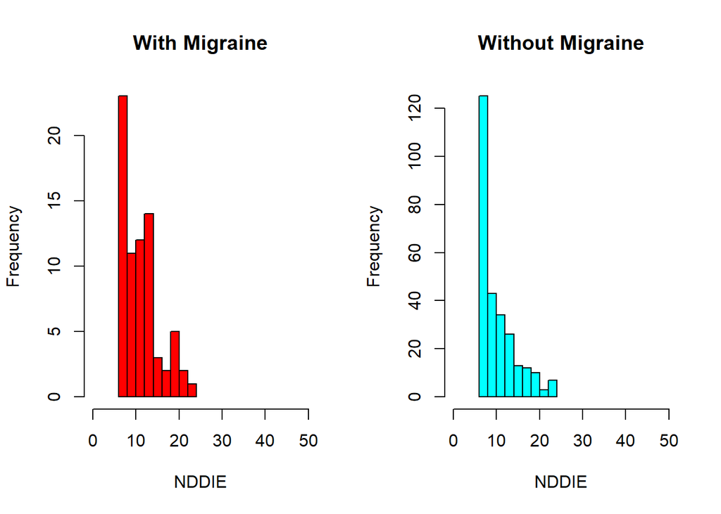

```r
par(mfrow = c(1,2))

hist(migraine$NDDIE[which(migraine$Migraine == 1)], xlim = c(0,50), col = 'red', xlab = 'NDDIE', main = 'With Migraine')
hist(migraine$NDDIE[which(migraine$Migraine == 0)], xlim = c(0,50), col = 'cyan', xlab = 'NDDIE', main = 'Without Migraine')
```

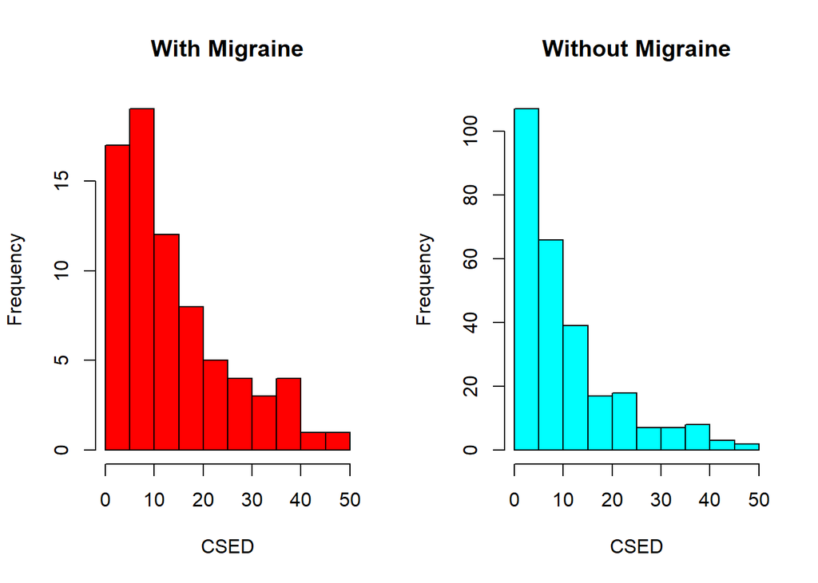

```r
hist(migraine$CESD[which(migraine$Migraine == 1)], xlim = c(0,50), col = 'red', xlab = 'CSED', main = 'With Migraine')
hist(migraine$CESD[which(migraine$Migraine == 0)], xlim = c(0,50), col = 'cyan', xlab = 'CSED', main = 'Without Migraine')
```

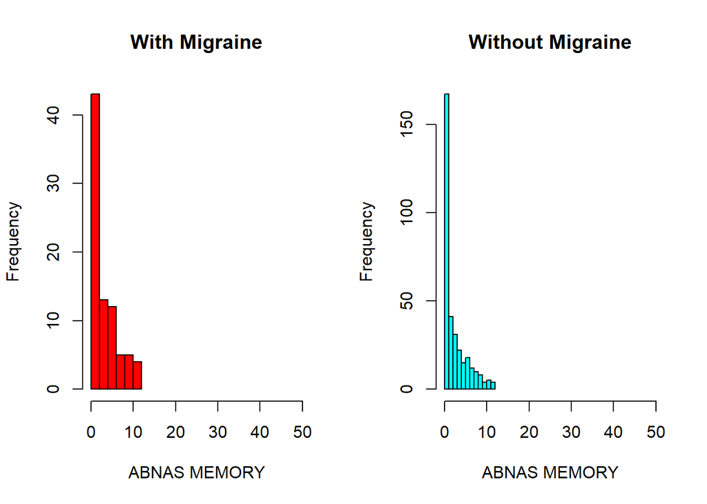

```r
hist(migraine$`ABNAS memory`[which(migraine$Migraine == 1)], xlim = c(0,50), col = 'red', xlab = 'ABNAS MEMORY', main = 'With Migraine')
hist(migraine$`ABNAS memory`[which(migraine$Migraine == 0)], xlim = c(0,50), col = 'cyan', xlab = 'ABNAS MEMORY', main = 'Without Migraine')
```

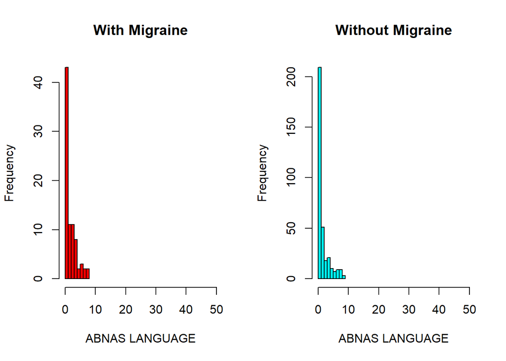

```r
hist(migraine$`ABNAS language`[which(migraine$Migraine == 1)], xlim = c(0,50), col = 'red', xlab = 'ABNAS LANGUAGE', main = 'With Migraine')
hist(migraine$`ABNAS language`[which(migraine$Migraine == 0)], xlim = c(0,50), col = 'cyan', xlab = 'ABNAS LANGUAGE', main = 'Without Migraine')
```

**We do the similar process as explained above using boxplots.**

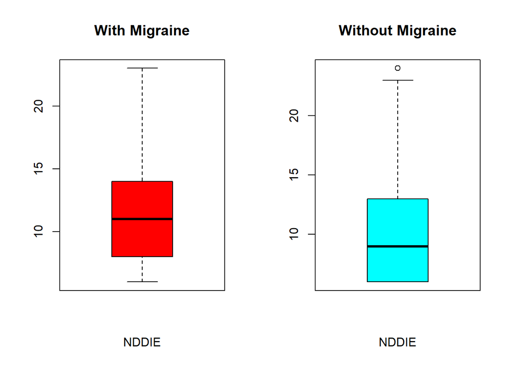

```r
layout(heights = c(5,5),T)
par(mfrow = c(1,2))

boxplot(migraine$NDDIE[which(migraine$Migraine == 1)], col = 'red', xlab = 'NDDIE', main = 'With Migraine')
boxplot(migraine$NDDIE[which(migraine$Migraine == 0)], col = 'cyan', xlab = 'NDDIE', main = 'Without Migraine')
```

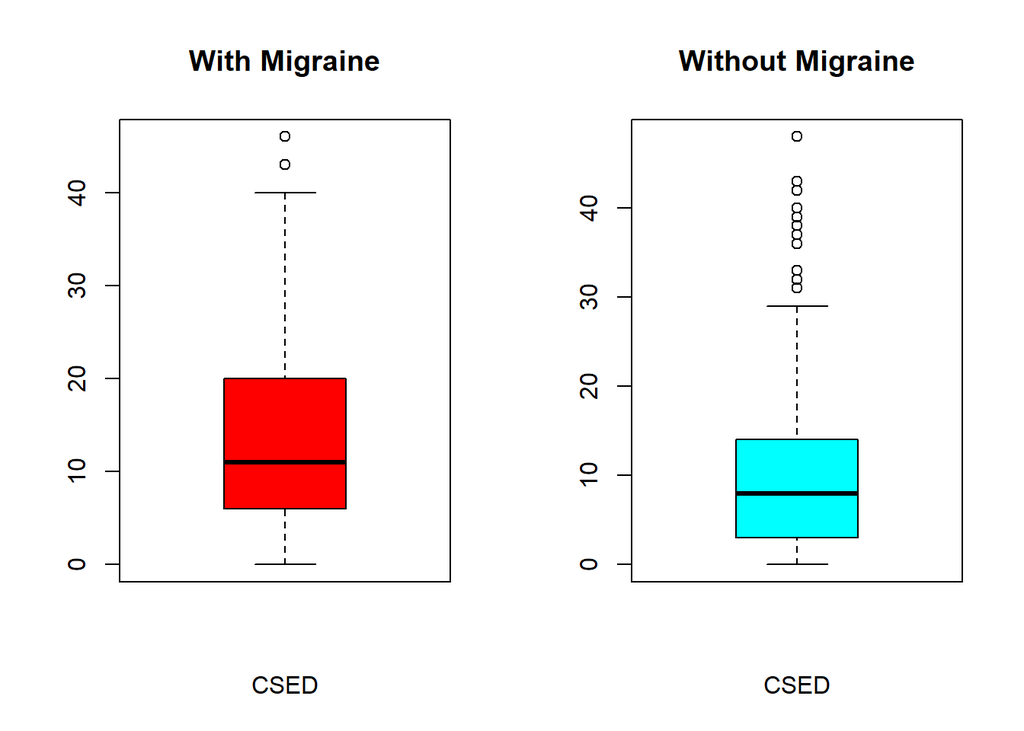

```r
boxplot(migraine$CESD[which(migraine$Migraine == 1)], col = 'red', xlab = 'CSED', main = 'With Migraine')
boxplot(migraine$CESD[which(migraine$Migraine == 0)], col = 'cyan', xlab = 'CSED', main = 'Without Migraine')
```

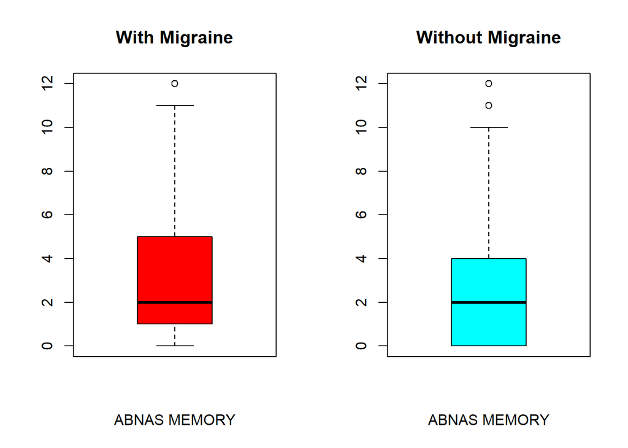

```r
boxplot(migraine$`ABNAS memory`[which(migraine$Migraine == 1)], col = 'red', xlab = 'ABNAS MEMORY', main = 'With Migraine')
boxplot(migraine$`ABNAS memory`[which(migraine$Migraine == 0)], col = 'cyan', xlab = 'ABNAS MEMORY', main = 'Without Migraine')
```

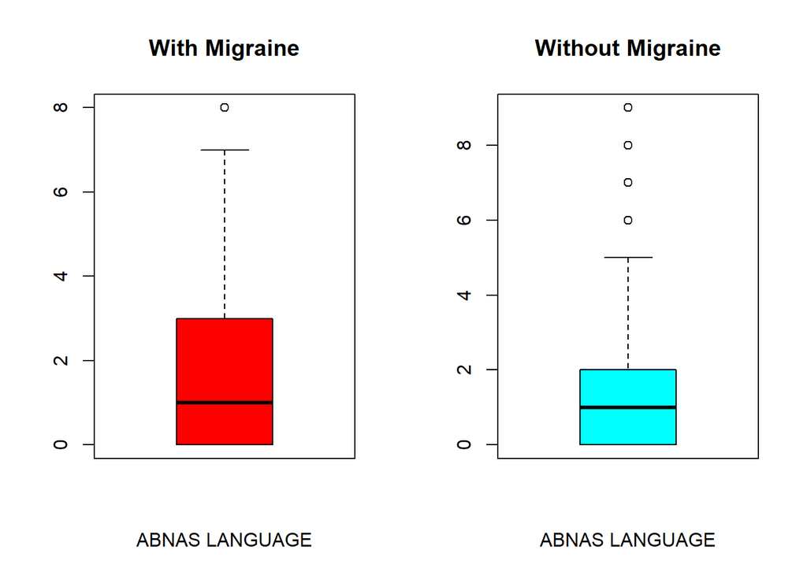

```r
boxplot(migraine$`ABNAS language`[which(migraine$Migraine == 1)], col = 'red', xlab = 'ABNAS LANGUAGE', main = 'With Migraine')
boxplot(migraine$`ABNAS language`[which(migraine$Migraine == 0)], col = 'cyan', xlab = 'ABNAS LANGUAGE', main = 'Without Migraine')
```